# Czynniki wpływające na czas rozwiązywania zadań z matematyki PISA 2015 - etap I

Zofia Nawalany, Michał Karlicki, Agata Gruszczyńska

22 marca 2017

# Spis treści

1.Cel  
2.Streszczenie etapu I  
3.Dane i ich preparatyka  
4.Wybór krajów  
5.Przerobienie danych na czas całego zadania  
6.Utworzone modele  
7.Wybór modelu  
8.Materiały dodatkowe

# 1.Cel

Celem pierwszego etapu projektu jest zbudowanie modelu liniowego na podstawie danych z PISA 2015, a dokładniej, modelu opartego o cechy zadania - jego ID oraz pozycję w kwestionariuszu.

# 2.Streszczenie etapu I

Wybrany przez nas model opisuje zależność między czasem całego zadania a jego pozycją z zagnieżdżonym ID zadania. Wybór oparliśmy o analizę wariancji ANOVA, która wskazała na istotną różnice pomiędzy tworzącymi się grupami. Zmienną objaśnianą stanowi zlogarytmowany czas wykonania całego zadania, który przyjmuje rozkład najbardziej zbliżony do rozkładu normalnego spośród przeanalizowanych (pkt 8).

# 3.Dane i ich preparatyka

Źródło danych do jego utworzenia stanowiła tabela PISA 2015 **“actionTimeScoreMath”, którą skrótowo nazwano w poniżej pracy “atsm”**.

```r
atsm<-actionTimeScoreMath
```

Przed przystąpieniem do analizy **ze zbioru usunięto wybrane wiersze**. Były to te, zawierające wartości **“-1” i “NA” w kolumnie “position”** oraz wartości **“NA” w kolumnie “T” bądź “CNT”**.

# 4.Wybór krajów

```r
atsm2<-atsm[atsm$CNT=="BRA      "|atsm$CNT=="SGP      "|atsm$CNT=="TTO      "|atsm$CNT=="TUN      "|atsm$CNT=="URY      "|atsm$CNT=="MAC      "|atsm$CNT=="PER      "|atsm$CNT=="MEX      "|atsm$CNT=="NZL      "|atsm$CNT=="DZA      "|atsm$CNT=="AUS      "|atsm$CNT=="CHL      "|atsm$CNT=="COL      "|atsm$CNT=="CRI      "|atsm$CNT=="DOM      "|atsm$CNT=="HKG      "|atsm$CNT=="IDN      "|atsm$CNT=="VNM      "|atsm$CNT=="ARG      ",]

atsm2<-atsm2[!atsm2$A=="0"| atsm2$S=="Full credit",]
```

# 5.Przerobienie danych na czas całego zadania

Dla tak przygotowanych danych stworzono analogiczną tabelę **atsm2** zawierającą zsumowany czas dla całego zadania.

# 6.Utworzone modele

Do utworzenia modeli posłużono się czasem transformowanym **log**. Na końcu w materiałach dodatkowych można znaleźć histogramy dla transformacji log i sqrt na podstawie których wytypowano, która transformacja czasu będzie najodpowiedniejsza. -model_liniowy1 - model badający zależność między czasem całego zadania a pozycją w kwestionariuszu -model_liniowy2 - model badajacy zależność między czasem całego zadania a ID zadania  
-model_liniowy3 - model badający zależności między czasem całego zadania a jego pozycją z zagnieżdżonym ID zadania

```r
model_liniowy1 <- lm(log(question_time)~position,data=atsm2)
model_liniowy2 <- lm(log(question_time)~item,data=atsm2)
model_liniowy3 <- lm(log(question_time)~position/item,data=atsm2)
```

# 7.Wybór modelu

Wybrany został model model_liniowy3.

```r
anova(model_liniowy1)
```

```
## Analysis of Variance Table
##
## Response: log(question_time)
##               Df Sum Sq Mean Sq F value    Pr(>F)
## position       3   7481 2493.67  3833.5 < 2.2e-16 ***
## Residuals 467554 304144    0.65
## ---
## Signif. codes:  0 '***' 0.001 '**' 0.01 '*' 0.05 '.' 0.1 ' ' 1
```

```r
anova(model_liniowy2)
```

```
## Analysis of Variance Table
##
## Response: log(question_time)
##               Df Sum Sq Mean Sq F value    Pr(>F)
## item          40  94318 2357.94  5072.9 < 2.2e-16 ***
## Residuals 467517 217307    0.46
## ---
## Signif. codes:  0 '***' 0.001 '**' 0.01 '*' 0.05 '.' 0.1 ' ' 1
```

```r
anova(model_liniowy3)
```

```
## Analysis of Variance Table
##
## Response: log(question_time)
##                   Df Sum Sq Mean Sq F value    Pr(>F)
## position           3   7481 2493.67  5602.5 < 2.2e-16 ***
## position:item    160  96105  600.66  1349.5 < 2.2e-16 ***
## Residuals     467394 208039    0.45
## ---
## Signif. codes:  0 '***' 0.001 '**' 0.01 '*' 0.05 '.' 0.1 ' ' 1
```

Dla wszystkich modeli analiza wariancji wskazuje na istotne różnice pomiędzy tworzącymi się grupami.

# 8.Materiały dodatkowe

Histogramy czasu bez transormacji i transformowanego przez logarytm oraz pierwiastek.

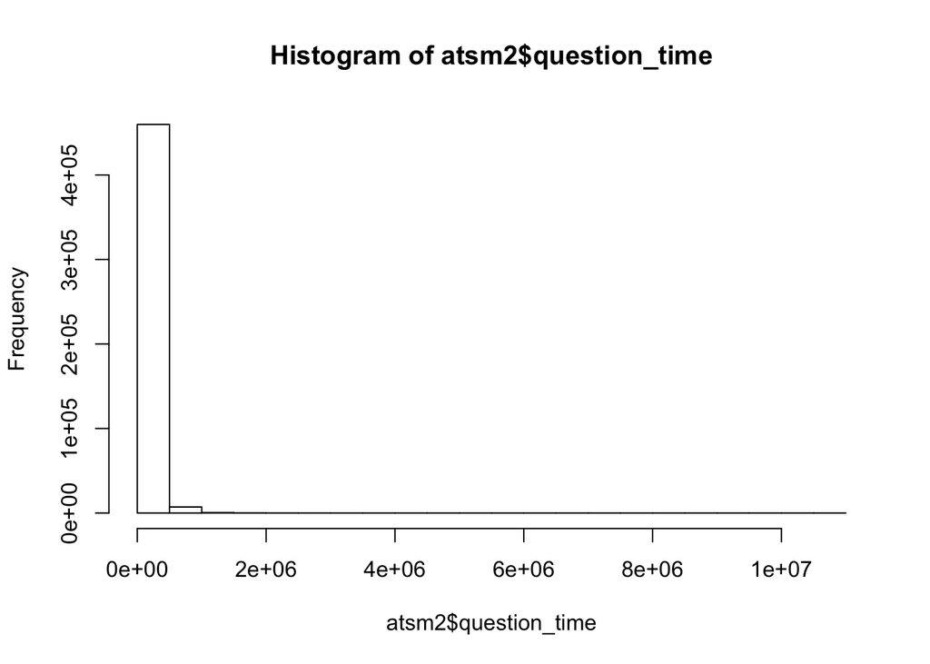

```r
hist(atsm2$question_time)
```

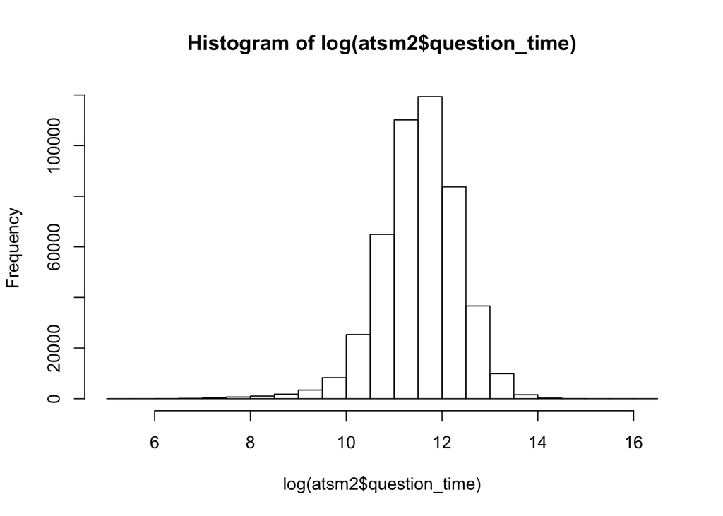

```r
hist(log(atsm2$question_time))
```

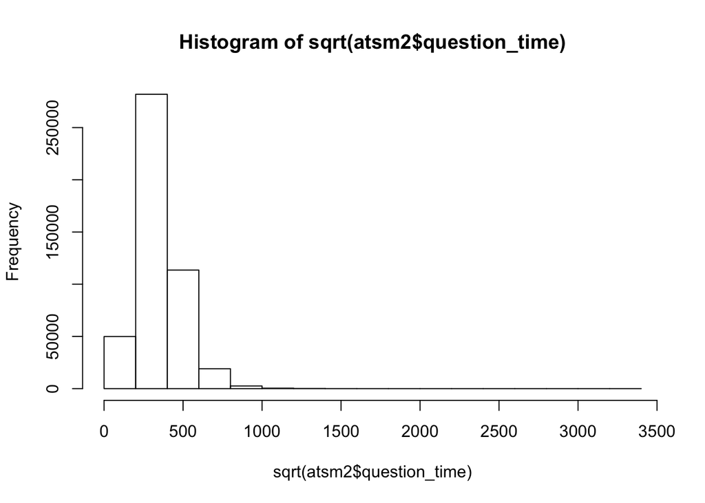

```r
hist(sqrt(atsm2$question_time))
```